# MAT_602_HW4_Chen

### MAT 602 HW4

#### Jiusheng Chen

##### 02/07/2017

##### 1. During week 3 we discussed the Pima Indian Diabetes data set from the UCI Machine Learning Repository. The data set contains a number of biological attributes from medical reports. All patients in the dataset are females at least 21 years old of Pima Indian heritage. The following chunk of code was used to load the data

```python
# Import libraries
import numpy as np
import urllib.request
# url with dataset
url = "http://archive.ics.uci.edu/ml/machine-learning-databases/pima-indians-diabetes/pima-indians-diabetes.data"
# download the file
raw_data = urllib.request.urlopen(url)
# load the CSV file as a numpy matrix
dataset = np.loadtxt(raw_data, delimiter=",")
# separate the data from the target attributes

print(dataset.shape)
X = dataset[:,0:8]
y = dataset[:,8]
print(dataset)
```

```
(768, 9)
[[   6.     148.      72.    ...,    0.627   50.       1.   ]
 [   1.      85.      66.    ...,    0.351   31.       0.   ]
 [   8.     183.      64.    ...,    0.672   32.       1.   ]
 ...,
 [   5.     121.      72.    ...,    0.245   30.       0.   ]
 [   1.     126.      60.    ...,    0.349   47.       1.   ]
 [   1.      93.      70.    ...,    0.315   23.       0.   ]]
```

##### (a) Use from sklearn.preprocessing import MinMaxScaler to rescale the attributes into the range between 0 and 1. Print the ﬁrst lines of the transformed data to conﬁrmed the rescaling.

```python
from sklearn.preprocessing import MinMaxScaler

# scaling the data using the MinMaxScaler
scale_X = MinMaxScaler((0,1)).fit_transform(X)

#printing the first row
print(scale_X[0])
```

```
[ 0.35294118  0.74371859  0.59016393  0.35353535  0.          0.50074516
  0.23441503  0.48333333]
```

##### (b) Usefrom sklearn.preprocessing import StandardScaler tostandardizethe observations (with a mean of 0 and a standard deviation of 1). Print the ﬁrst lines of the transformed data and conﬁrm the standardization.

```python
from sklearn.preprocessing import StandardScaler

# scaling the data using the StandardScaler
standard_scale_X = StandardScaler().fit_transform(X)
# printing the first row
print(standard_scale_X[0])
```

```
[ 0.63994726  0.84832379  0.14964075  0.90726993 -0.69289057  0.20401277
  0.46849198  1.4259954 ]
```

##### 2. A useful approach to select relevant features from a dataset is to use a random forest, an ensemble technique available in scikit-learn. Consider the Boston housing data set that gives housing values and other statistics in each of 506 suburbs of Bostonbased on a 1970 census. We used this data set before in the CIS 544 Data Mining and Machine Learning course, and explored random forest techniques using R. (You can check your notes or the file DecisionTrees.html uploaded to Ember). The random forest implementation in scikit-learn already collects feature importances for us so that we can access them via the feature*importances* attribute after fitting a RandomForestClassifier. Find the three most relevant features. The chunk of code below loads the Boston housing data set

```python
# Import the libraries.
from sklearn.datasets import load_boston
import pandas as pd
import numpy as np

# Import Boston data set and sane it in a variable called 'boston'.
boston = load_boston()

# Convert boston.data into a pandas data frame.
bos = pd.DataFrame(boston.data)

# Replace current column names, which are just numbers, with the feature names.
bos.columns = boston.feature_names

# Since 'boston.target' contains the housing prices, we can add these target prices to the 'bos' data frame as follows:
bos['MEDV'] = boston.target

# Assign class labels to each of the 506 Boston houses in terms of whether their prices are below the first quartile, in
# between the first quartile and the median, in between the median and the third quartile or above the third quartile,
# which will correspond to class labels of prices with regards to 'low', 'fair', 'high' or 'very high', respectively.
bos['Class_Labels'] = np.where(bos['MEDV'] < np.percentile(bos['MEDV'].values, 25),'low',
                        np.where((bos['MEDV'] > np.percentile(bos['MEDV'].values, 25)) & (bos['MEDV'] < np.median(bos['MEDV'].values)),'fair',
                            np.where((bos['MEDV'] > np.median(bos['MEDV'].values)) & (bos['MEDV'] < np.percentile(bos['MEDV'].values, 75)),'high','very high')))

# Print the dataframe.
bos.head()
```

|  | CRIM | ZN | INDUS | CHAS | NOX | RM | AGE | DIS | RAD | TAX | PTRATIO | B | LSTAT | MEDV | Class_Labels |
| --- | --- | --- | --- | --- | --- | --- | --- | --- | --- | --- | --- | --- | --- | --- | --- |
| 0 | 0.00632 | 18.0 | 2.31 | 0.0 | 0.538 | 6.575 | 65.2 | 4.0900 | 1.0 | 296.0 | 15.3 | 396.90 | 4.98 | 24.0 | high |
| 1 | 0.02731 | 0.0 | 7.07 | 0.0 | 0.469 | 6.421 | 78.9 | 4.9671 | 2.0 | 242.0 | 17.8 | 396.90 | 9.14 | 21.6 | high |
| 2 | 0.02729 | 0.0 | 7.07 | 0.0 | 0.469 | 7.185 | 61.1 | 4.9671 | 2.0 | 242.0 | 17.8 | 392.83 | 4.03 | 34.7 | very high |
| 3 | 0.03237 | 0.0 | 2.18 | 0.0 | 0.458 | 6.998 | 45.8 | 6.0622 | 3.0 | 222.0 | 18.7 | 394.63 | 2.94 | 33.4 | very high |
| 4 | 0.06905 | 0.0 | 2.18 | 0.0 | 0.458 | 7.147 | 54.2 | 6.0622 | 3.0 | 222.0 | 18.7 | 396.90 | 5.33 | 36.2 | very high |

```python
# All values of the features in the Boston dataset.
X = bos.iloc[:,:-2].values
# All values of the target variable.
y = bos['Class_Labels'].values

# Used the 'train_test_split' function and set 'test_size' = 0.3 to randomly split 'X' and 'y' into separate training
# and test datasets, where 70 percent of the samples were assigned to 'X_train' and 'y_train', and 30 percent to
# 'X_test' and 'y_test', respectively.
from sklearn.model_selection import train_test_split

X_train, X_test, y_train, y_test = train_test_split(X, y, test_size=0.3, random_state=0)
```

```
Feature ranking:
 1) RM                             0.198295
 2) LSTAT                          0.192132
 3) CRIM                           0.093749
 4) AGE                            0.085907
 5) DIS                            0.079077
 6) PTRATIO                        0.069387
 7) NOX                            0.068276
 8) B                              0.058836
 9) INDUS                          0.056980
10) TAX                            0.053527
11) RAD                            0.023159
12) ZN                             0.011297
13) CHAS                           0.009379
```

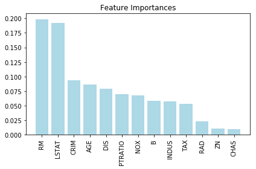

```python
from sklearn.ensemble import RandomForestClassifier

# Train a forest of 10,000 trees on the Boston dataset and rank all features by their respective importance measures.
forest = RandomForestClassifier(n_estimators = 10000,
                               random_state = 0,
                               n_jobs = -1)
forest.fit(X_train, y_train)

# Import libraries.
import numpy as np
import matplotlib.pyplot as plt

# Store the feature names in the variable 'feat_labels'.
feat_labels = bos.columns[:-2]

# Store the importances of the features in the variable 'importances'.
importances = forest.feature_importances_

# Get sort indices in descending order.
indices = np.argsort(importances)[::-1]

# Print the feature ranking.
print("Feature ranking:")

for f in range(X_train.shape[1]):
    print("%2d) %-*s %f" % (f + 1, 30,
                            feat_labels[indices[f]],
                            importances[indices[f]]))

# Plot the feature importances of the forest.
plt.title('Feature Importances')
plt.bar(range(X_train.shape[1]),
        importances[indices],
        color='lightblue',
        align='center')
plt.xticks(range(X_train.shape[1]),
           feat_labels[indices], rotation=90)
plt.xlim([-1, X_train.shape[1]])
plt.tight_layout()
plt.show()
```

```python
from sklearn.feature_selection import SelectFromModel

# Create a selector object that will use the random forest classifier to identify the three most relevant features,
# which, based on the results from the previous chunk of code, we can conclude that it corresponds to an importance of
# greater than or equal to 0.09.
sfm = SelectFromModel(forest, threshold = 0.09, prefit=True)

# Reduce 'X_train' to the selected features.
X_selected = sfm.transform(X_train)
X_selected.shape
```

```
(354, 3)
```

```python
# Print the names of the most important features.
for f in range(X_selected.shape[1]):
    print("%2d) %-*s %f" % (f + 1, 30,
                            feat_labels[indices[f]],
                            importances[indices[f]]))
```

```
 1) RM                             0.198295
 2) LSTAT                          0.192132
 3) CRIM                           0.093749
```

#### For this question, I make the reference from Rojas, Because It didn't show the correct to me, and I also have some problem to the column feature.

##### 3. Read the ﬁrst pages of Chapter 12 "Training Artiﬁcial Neural Networks" of our textbook (pages 341 to 347), and write a short summary of

##### (a) Modeling complex functions with artiﬁcial neural networks

An artificial neural network is an artificial intelligence tool that sees and makes the production of arbitrary nonlinear multiparametric discriminant functions from the experimental data feeded in the system. The application of artificial neural network has attained an increased popularity for the applications where there was a use of mechanistic description of the dependency between dependent and independent variables.

##### (b) Single-layer neural network recap

The simplest kind of neural network is a single-layer perceptron network, that has single layer of output nodes. The inputs would be provided into the outputs with the series of weights.